# Explore physiological depressive symptoms profiles among Mexican-origin adolescents and its familial antecedents

Tianlu Zhang

2024-12-12

# 1 Introduction

## 1.1 Research question

Emerging research studying depression found that there are different types of depression in terms of the biographic symptoms.

Lamers et al.(2020) posits that there are four profiles of depression, within which “Immuno-metabolic depression” represents a particular ‘sub-type’ (see picture below) of depression characterized by distinct symptom profile (e.g., increased appetite and weight gain) and increased inflammatory and metabolically markers. Persons with immuno-metabolic depressive symptoms may be the most important group to target in prevention programs for cardiometabolic disease, and may benefit most from treatments targeting immuno-metabolic pathways. This is particularly important to study Latino adolescents as this group was found to suffered from metabolic & cardiovascular disease such as obesity.Therefore, it is important to recognize this group and explore the risk and protective factors for it.

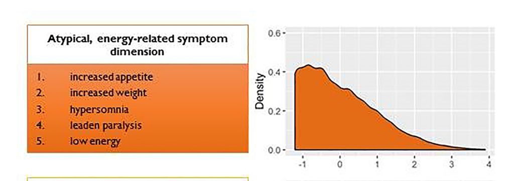

## 1.3 Research aim

This study aims to identify the high-risk “Immuno-metabolic depression” in Mexican-origin adolescents with high biological & psychological risks by integrating biomakers (CRP,IL-6, HDL, A1C, systolic blood pressure, diastolic blood pressure, BMI percentiles) and self-report depressive symptom & anxiety data using latent profile analyses.

## 1.4 Hypotesis

Because the Latent Profile Analysis (LPA) is an exploratory technic. There is no specific hypothesis about the profile results. Rather, the current study expects there is a Immuno-metabolic depressive symptoms with high depressive symptoms, anxiety, high inflammation and metabolic risks. Besides that, there will also be a profile with high depressive symptoms and anxiety but no inflammation and metabolic risks, and another profile with high inflammation and metabolic risks but no high depressive symptoms and anxiety.

# 2 Methods

### 2.1 Data

The data for this study is from a three-wave longitudinal data across early (Wave 1: 2012 – 2015), middle (Wave 2: 2013 – 2016), to late adolescence (Wave 3: 2017 - 2020) focused on Mexican immigrant families in central Texas. Adolescents who provided dried blood spots (DBS) samples, blood pressure, and weight/height data during Wave 3 home visits were included in the current study. All variables using in latent profile analyses are from Wave 3

### 2.2 Variables

  Inflammation biomakers include: CRP, IL-6 were (from DBS sample),Metabolic system biomakers include: HDL, A1C, blood pressure, BMI percentiles

### 2.3 Analyses methods

Latent Profile Analysis (LPA) is a statistical technique used to identify distinct subgroups (profiles) within a population based on continuous observed variables. LPA models the probability that an individual belongs to a latent class (profile) based on their observed values across several continuous variables. Each profile is characterized by its unique mean vector and variance-covariance structure for these variables.

# 3 Results

### 3.1 Data cleaning

#### 3.1.1 Loading packages

```r
library(tidyverse)
library(stringr)
library(dplyr)
library(MplusAutomation)
library(bruceR)
library(skimr)
library(kableExtra) #for table formatting
library(papaja) #for apa
library(table1)
library(tidyLPA) #for latent profile analyses
```

```r
library(scales)
library(DataExplorer)
library(foreign)
library(nnet) #nnet package to estimate a multinomial logistic regression model
library(ggplot2)
library(reshape2)
```

#### 3.1.2 Importing & selecting samples for LPA

Data cleaning was conducted to include those individuals provided all biomakers - Because LPA could be biased when one participants not provide all varible values. This study only chooses those samples provided complete data in all variables

```r
df <- import("./rprojectdata.sav")
#skim(df)
View(df)

#check the missing data patterns first using the DataExplorer package (profile_missing)
#use kbl function to make publishable table
df %>%
  select(c(CRP_3SDWlg, IL_6plus1_lg, HDL_3SDWlg,
           BE_A1c_3SDWlg, t3bpsy_3SDWlg, t3bpdi_3SDWlg,
           t3bmip_reco, t3cort_1_wzlg, t3cesd, t3anx)) %>%
  profile_missing(.) %>%
  mutate(pct_missing = round(pct_missing, 3)) %>%
  arrange(desc(pct_missing)) %>%
  kbl(caption = "Prevalence of Missing Data") %>%
  kable_classic(full_width = FALSE)
```

Prevalence of Missing Data

| feature | num_missing | pct_missing |
| --- | --- | --- |
| t3cort_1_wzlg | 303 | 0.502 |
| CRP_3SDWlg | 279 | 0.462 |
| IL_6plus1_lg | 279 | 0.462 |
| HDL_3SDWlg | 279 | 0.462 |
| BE_A1c_3SDWlg | 279 | 0.462 |
| t3bmip_reco | 279 | 0.462 |
| t3bpsy_3SDWlg | 270 | 0.447 |
| t3bpdi_3SDWlg | 270 | 0.447 |
| t3cesd | 270 | 0.447 |
| t3anx | 270 | 0.447 |

```r
##the missing data percentage is relative high as this dataset combined Wave1-Wave 3 data. Half participants dropped at Wave 3 compared with Wave 1

#check how many cases have complete data in all variables
samplesize <- df %>%
  select(c(CRP_3SDWlg, IL_6plus1_lg, HDL_3SDWlg,
           BE_A1c_3SDWlg, t3bpsy_3SDWlg, t3bpdi_3SDWlg,
           t3bmip_reco, t3cort_1_wzlg, t3cesd, t3anx)) %>%
  filter(complete.cases(.)) %>%
  nrow()
##282 complete cases

#creat sub-dataset for complete samples
df1 <- df %>%
  filter(complete.cases(select(., CRP_3SDWlg, IL_6plus1_lg, HDL_3SDWlg,
                               BE_A1c_3SDWlg, t3bpsy_3SDWlg, t3bpdi_3SDWlg,
                               t3bmip_reco, t3cort_1_wzlg, t3cesd, t3anx)))
View(df1)
nrow(df1)
```

```
## [1] 282
```

### 3.2 Demographic characteristics transfer & summary

```r
df1 <- df1 %>%
  mutate(t1gender = factor(t1gender,
                           levels = c(0, 1),
                           labels = c("female", "male")))
Freq(df1$t1gender)
```

```
## Frequency Statistics:
## ────────────────
##           N    %
## ────────────────
## female  154 54.6
## male    128 45.4
## ────────────────
## Total N = 282
```

```r
female_percent <- percent(
  sum(df1$t1gender == "female", na.rm = TRUE)/samplesize, accuracy = 0.1)

df1 <- df1 %>%
  mutate(t1born = factor(t1born,
                           levels = c(1, 2),
                           labels = c("U.S.", "Mexica")))
Freq(df1$t1born)
```

```
## Frequency Statistics:
## ────────────────
##           N    %
## ────────────────
## U.S.    215 76.2
## Mexica   67 23.8
## ────────────────
## Total N = 282
```

```r
usborn <- percent(
  sum(df1$t1born == "U.S.", na.rm = TRUE)/samplesize, accuracy = 0.1)

df1 <- df1 %>%
  mutate(m3educ = factor(m3educ,
                         levels = c(1, 2, 3, 4, 5, 6, 7, 8, 9, 10, 11),
                         labels = c("No formal schooling",
                                    "Some elementary school",
                                    "Finished elementary school",
                                    "Some middle school/junior high school",
                                    "Finished middle school/junior high school",
                                    "Some high school",
                                    "Finished high school",
                                    "Finished technical or vocational training",
                                    "Finished community college degree (AA)",
                                    "Finished university/bachelor degree (BA/BS)",
                                    "Finished graduate degree")))
Freq(df1$m3educ)
```

```
## Frequency Statistics:
## ────────────────────────────────────────────────────
##                                               N    %
## ────────────────────────────────────────────────────
## No formal schooling                          10  3.5
## Some elementary school                       19  6.7
## Finished elementary school                   42 14.9
## Some middle school/junior high school        28  9.9
## Finished middle school/junior high school    66 23.4
## Some high school                             26  9.2
## Finished high school                         31 11.0
## Finished technical or vocational training    29 10.3
## Finished community college degree (AA)        6  2.1
## Finished university/bachelor degree (BA/BS)  19  6.7
## Finished graduate degree                      2  0.7
## (NA)                                          4  1.4
## ────────────────────────────────────────────────────
## Total N = 282
## Valid N = 278
```

```r
# Round all values to use insert into manuscript
Mwave1_age <- round(mean(df1$t1age_new, na.rm = TRUE), 1)
Mwave1_age_sd <- round(sd(df1$t1age_new, na.rm = TRUE), 1)
Mwave2_age <- round(mean(df1$t2age_new, na.rm = TRUE), 1)
Mwave2_age_sd <- round(sd(df1$t2age_new, na.rm = TRUE), 1)
Mwave3_age <- round(mean(df1$t3age_new, na.rm = TRUE), 1)
Mwave2_age_sd <- round(sd(df1$t2age_new, na.rm = TRUE), 1)
```

### 3.3 Summary for variables using for LPA

```r
#take a gimps of all variables
df1 %>%
  select(c(CRP_3SDWlg, IL_6plus1_lg, HDL_3SDWlg,
           BE_A1c_3SDWlg, t3bpsy_3SDWlg, t3bpdi_3SDWlg,
           t3bmip_reco, t3cesd, t3anx)) %>%
  summary(across(everything(.)))
```

```
##    CRP_3SDWlg     IL_6plus1_lg       HDL_3SDWlg    BE_A1c_3SDWlg
##  Min.   :2.387   Min.   :0.00000   Min.   :1.176   Min.   :0.6232
##  1st Qu.:3.584   1st Qu.:0.06508   1st Qu.:1.699   1st Qu.:0.7076
##  Median :3.969   Median :0.12821   Median :1.813   Median :0.7243
##  Mean   :4.029   Mean   :0.11611   Mean   :1.790   Mean   :0.7252
##  3rd Qu.:4.458   3rd Qu.:0.16579   3rd Qu.:1.903   3rd Qu.:0.7404
##  Max.   :5.461   Max.   :0.53479   Max.   :2.110   Max.   :0.8494
##  t3bpsy_3SDWlg   t3bpdi_3SDWlg    t3bmip_reco         t3cesd
##  Min.   :1.916   Min.   :1.620   Min.   :0.0000   Min.   :1.000
##  1st Qu.:2.025   1st Qu.:1.778   1st Qu.:0.5602   1st Qu.:1.300
##  Median :2.059   Median :1.820   Median :0.8315   Median :1.450
##  Mean   :2.063   Mean   :1.818   Mean   :0.7261   Mean   :1.535
##  3rd Qu.:2.098   3rd Qu.:1.859   3rd Qu.:0.9568   3rd Qu.:1.700
##  Max.   :2.198   Max.   :1.974   Max.   :1.0000   Max.   :3.650
##      t3anx
##  Min.   :1.00
##  1st Qu.:1.25
##  Median :1.75
##  Mean   :1.83
##  3rd Qu.:2.25
##  Max.   :4.00
```

```r
df_plot <- df1 %>%
  select(c(CRP_3SDWlg, IL8w_1lg, IL_6plus1_lg, HDL_3SDWlg,
           BE_A1c_3SDWlg, t3bpsy_3SDWlg, t3bpdi_3SDWlg,
           t3bmip_reco, t3cesd, t3anx)) %>%
  rename(.,
         "CRP" = "CRP_3SDWlg",
         "IL8" = "IL8w_1lg",
         "IL6" = "IL_6plus1_lg",
         "HDL" = "HDL_3SDWlg",
         "A1c" = "BE_A1c_3SDWlg",
         "systolic_bp" = "t3bpsy_3SDWlg",
         "diastolic_dp" = "t3bpdi_3SDWlg",
         "BMI_percentile" = "t3bmip_reco",
         "depressive_symptoms" = "t3cesd",
         "anxiety" = "t3anx") %>%
  pivot_longer(cols = everything(),
               names_to = "variables",
               values_to = "values")
View(df_plot)

# make publishable table
descriptive <- df_plot %>%
  group_by(variables) %>%
  summarise(
    Mean = mean(values, na.rm = TRUE),
    Median = median(values, na.rm = TRUE),
    Min = min(values, na.rm = TRUE),
    Max = max(values, na.rm = TRUE),
    SD = sd(values, na.rm = TRUE))

descriptive %>%
  kable(caption =
          "Table 1. Descriptive statistics of variables",
        digits = 3,
        align = "l") %>% ##
  kable_classic_2(full_width = FALSE)
```

Table 1. Descriptive statistics of variables

| variables | Mean | Median | Min | Max | SD |
| --- | --- | --- | --- | --- | --- |
| A1c | 0.725 | 0.724 | 0.623 | 0.849 | 0.031 |
| BMI_percentile | 0.726 | 0.832 | 0.000 | 1.000 | 0.275 |
| CRP | 4.029 | 3.969 | 2.387 | 5.461 | 0.630 |
| HDL | 1.790 | 1.813 | 1.176 | 2.110 | 0.159 |
| IL6 | 0.116 | 0.128 | 0.000 | 0.535 | 0.082 |
| IL8 | 0.462 | 0.435 | 0.155 | 0.958 | 0.157 |
| anxiety | 1.830 | 1.750 | 1.000 | 4.000 | 0.673 |
| depressive_symptoms | 1.535 | 1.450 | 1.000 | 3.650 | 0.371 |
| diastolic_dp | 1.818 | 1.820 | 1.620 | 1.974 | 0.058 |
| systolic_bp | 2.063 | 2.059 | 1.916 | 2.198 | 0.050 |

```r
  #column_spec(2, width_min = "1.5in")
```

### 3.4 Visualization of variables

Here I want to plot all of my variables using for LPA to check of there are any mistakes.

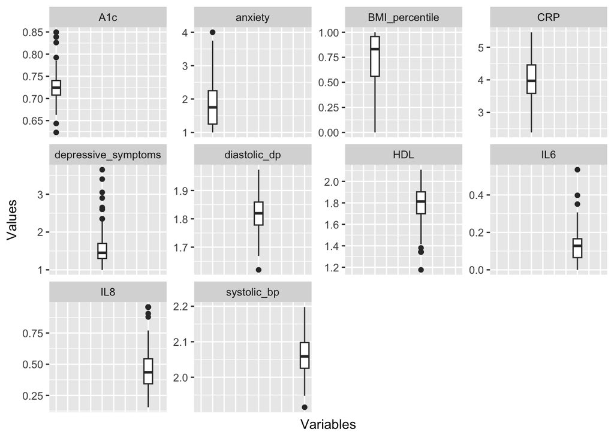

### 3.5 Run latent profile analysis in R using tidyLPA package

Here is how it looks like when using MPLUS to do LPA, which is really time-consuming (See piscture below). tidyLPA package developed by Rosenberg et al.(2018) can achieved the same LPA analyses with really simple codes.

[figure not shown]

LPA is based on how we choose the variance & covariance matrix. In this study, the variances were set to varying across different profiles and covariance were set to zero to assist interpretation. The matrix looks like:

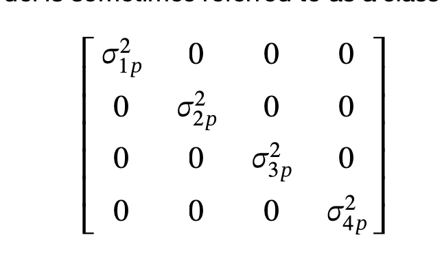

(Pastor et al., 2007)

```r
model <- df1%>%
  select(c(CRP_3SDWlg, IL_6plus1_lg, HDL_3SDWlg,
           BE_A1c_3SDWlg, t3bpsy_3SDWlg, t3bpdi_3SDWlg,
           t3bmip_reco, t3cesd, t3anx)) %>%
  estimate_profiles(1:6, package = "mplus", ANALYSIS = "starts = 200, 50;",
                    variances = "varying", covariances = "zero")
model
```

```
## tidyLPA analysis using mplus:
##
##  Model Classes AIC      BIC      Entropy prob_min prob_max n_min n_max BLRT_p
##  2     1       -2249.10 -2183.54 1.00    1.00     1.00     1.00  1.00
##  2     2       -2658.49 -2523.74 0.87    0.96     0.97     0.36  0.64  0.00
##  2     3       -2831.84 -2627.90 0.83    0.88     0.97     0.22  0.44  0.00
##  2     4       -2906.12 -2632.98 0.85    0.86     0.97     0.14  0.36  0.00
##  2     5       -2943.28 -2600.94 0.85    0.90     0.96     0.16  0.29  0.00
##  2     6       -2984.22 -2572.68 0.85    0.84     0.95     0.10  0.27  0.00
```

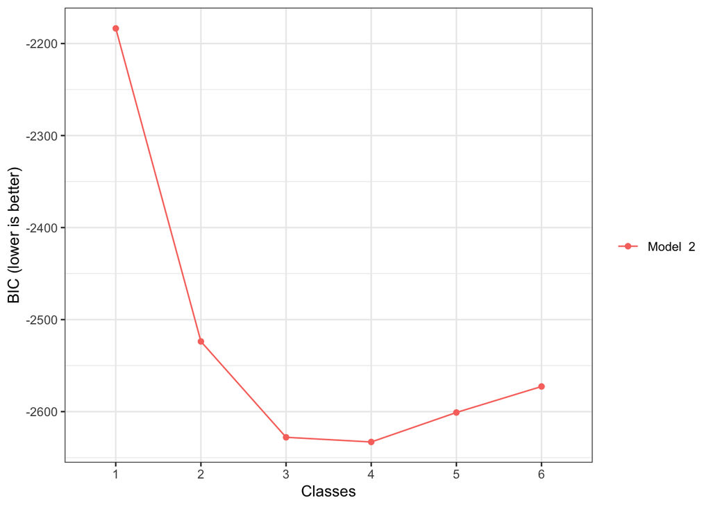

```r
plot(model)
```

```r
?estimate_profiles

model[["model_2_class_4"]][["dff"]][['Class']] %>%
  table() %>%
  prop.table()
```

```
## .
##         1         2         3         4
## 0.1666667 0.3581560 0.1382979 0.3368794
```

```r
#seems the 4-profile solution is the best, so i choose it as my final solution
model4 <- model[4]
```

### 3.6 Compare different biomaker values across profiles

After LPA, we hope to see variable values in different profiles and if there are significant difference on each variables. Therefore, anova was conducted to compare values of each variables.

In this section, I used a handy table1 function to directly output the table describing the variables and the difference between them.

```r
profiledata <- get_data(model4[[1]])
View(profiledata)
profiledata$Class <- factor(profiledata$Class,
                              levels = c(1, 2, 3, 4))
Freq(profiledata$Class)
```

```
## Frequency Statistics:
## ───────────
##      N    %
## ───────────
## 1   47 16.7
## 2  101 35.8
## 3   39 13.8
## 4   95 33.7
## ───────────
## Total N = 282
```

```r
pvalue_anova <- function(x, ...) {
  # Construct vectors of data y, and groups (strata) g
  y <- unlist(x)
  g <- factor(rep(1:length(x), times=sapply(x, length)))
  p <- anova(lm(y ~ g ))$`Pr(>F)`[1]
  c("", sub("<", "&lt;", format.pval(p, digits=3, eps=0.001)))
  }

my.render.cont <- function(x) {
  # Apply rounding and formatting to continuous variables, rounding all to 3 digits
  rounded_stats <- stats.apply.rounding(stats.default(x), digits = 3)

  # Ensure that the stats are numeric before formatting
  MEAN <- as.numeric(rounded_stats$MEAN)
  SD <- as.numeric(rounded_stats$SD)
  MEDIAN <- as.numeric(rounded_stats$MEDIAN)

  c(" " = "",  # Leave a blank line for the variable name
    "Mean (SD)" = sprintf("%3.3f (&plusmn; %3.3f)", MEAN, SD),
    "Median" = sprintf("%3.3f", MEDIAN))
}


table1::table1(~ CRP_3SDWlg + IL_6plus1_lg + HDL_3SDWlg +
                 BE_A1c_3SDWlg + t3bpsy_3SDWlg + t3bpdi_3SDWlg +
                 t3bmip_reco + t3cesd + t3anx | Class,
               data = profiledata,
               overall = FALSE,  # Don't include overall stats
               render.continuous = my.render.cont,
               extra.col = list(`P-value for ANOVA`=pvalue_anova))
```

|  | 1 (N=47) | 2 (N=101) | 3 (N=39) | 4 (N=95) | P-value for ANOVA |
| --- | --- | --- | --- | --- | --- |
| log CRP WAVE3 winsorize |  |  |  |  |  |
| Mean (SD) | 3.800 (± 0.524) | 3.920 (± 0.622) | 3.520 (± 0.392) | 4.470 (± 0.483) | <0.001 |
| Median | 3.750 | 3.830 | 3.500 | 4.450 |  |
| IL_6plus1 then log |  |  |  |  |  |
| Mean (SD) | 0.108 (± 0.079) | 0.111 (± 0.100) | 0.146 (± 0.035) | 0.113 (± 0.074) | 0.106 |
| Median | 0.136 | 0.120 | 0.141 | 0.126 |  |
| log HDL WAVE3 winsorize |  |  |  |  |  |
| Mean (SD) | 1.790 (± 0.153) | 1.790 (± 0.160) | 1.910 (± 0.064) | 1.750 (± 0.166) | <0.001 |
| Median | 1.790 | 1.830 | 1.910 | 1.760 |  |
| log BE_A1c WAVE3 winsorize |  |  |  |  |  |
| Mean (SD) | 0.717 (± 0.025) | 0.725 (± 0.029) | 0.713 (± 0.023) | 0.734 (± 0.035) | <0.001 |
| Median | 0.724 | 0.724 | 0.716 | 0.732 |  |
| log t3bpsy winsorize |  |  |  |  |  |
| Mean (SD) | 2.060 (± 0.052) | 2.050 (± 0.044) | 2.020 (± 0.021) | 2.090 (± 0.043) | <0.001 |
| Median | 2.060 | 2.050 | 2.020 | 2.090 |  |
| log t3bpdi winsorize |  |  |  |  |  |
| Mean (SD) | 1.820 (± 0.066) | 1.810 (± 0.051) | 1.780 (± 0.041) | 1.840 (± 0.056) | <0.001 |
| Median | 1.820 | 1.810 | 1.770 | 1.850 |  |
| t3bmip/100 |  |  |  |  |  |
| Mean (SD) | 0.667 (± 0.259) | 0.623 (± 0.246) | 0.480 (± 0.275) | 0.966 (± 0.022) | <0.001 |
| Median | 0.722 | 0.683 | 0.504 | 0.966 |  |
| t3 depressive symptoms |  |  |  |  |  |
| Mean (SD) | 2.090 (± 0.458) | 1.300 (± 0.141) | 1.590 (± 0.186) | 1.490 (± 0.233) | <0.001 |
| Median | 2.000 | 1.300 | 1.600 | 1.450 |  |
| Teen W3 Anxiety |  |  |  |  |  |
| Mean (SD) | 2.770 (± 0.504) | 1.450 (± 0.383) | 2.040 (± 0.498) | 1.690 (± 0.583) | <0.001 |
| Median | 2.750 | 1.330 | 2.000 | 1.500 |  |

### 3.7 Visualization

In this section, I want to visualize the result and give a more direct picture showing the difference between profiles. Therefore, ggplot together with bar plot was used to complete this.

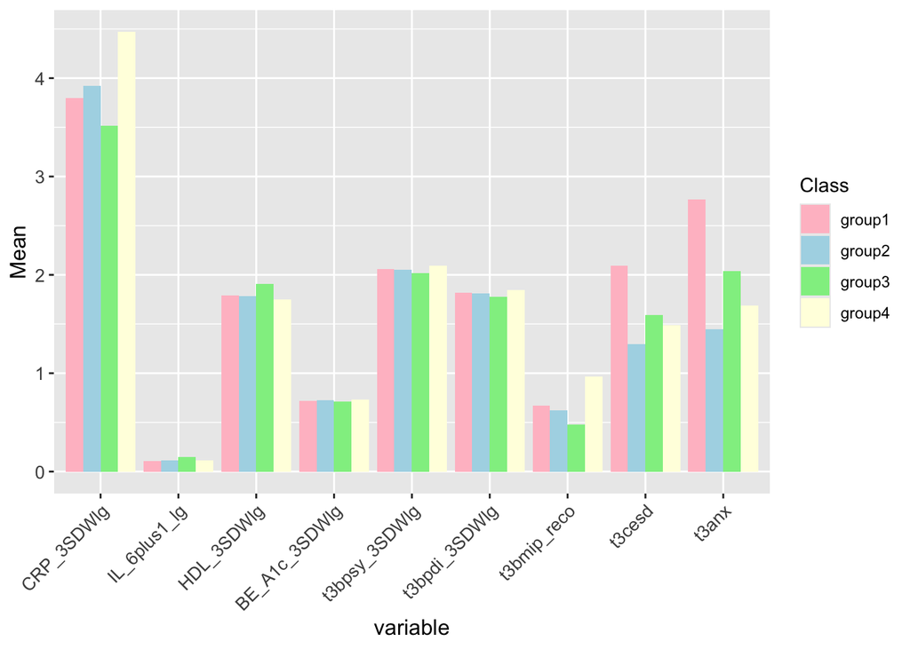

```r
long_profiledata <- profiledata %>%
  select(c(CRP_3SDWlg, IL_6plus1_lg, HDL_3SDWlg,
         BE_A1c_3SDWlg, t3bpsy_3SDWlg, t3bpdi_3SDWlg,
         t3bmip_reco, t3cesd, t3anx, Class)) %>%
  pivot_longer(cols = -Class, names_to = "variable", values_to = "value")

View(long_profiledata)

long_profiledata$Class <- factor(long_profiledata$Class,
                                 levels = c(1,2,3,4),
                                 labels = c("group1",
                                            "group2",
                                            "group3",
                                            "group4"))

long_profiledata$variable <- factor(long_profiledata$variable,
                                    levels = c("CRP_3SDWlg", "IL_6plus1_lg", "HDL_3SDWlg",
                                               "BE_A1c_3SDWlg", "t3bpsy_3SDWlg",
                                               "t3bpdi_3SDWlg",
                                               "t3bmip_reco", "t3cesd", "t3anx"))

long_profiledata %>%
  group_by(Class, variable) %>%
  summarise(Mean = mean(value, na.rm = TRUE), .groups = 'drop') %>%
  ggplot(aes(x = variable, y = Mean, fill = Class)) +
  geom_bar(stat = "identity", position = "dodge") +
  scale_fill_manual(values = c("pink", "lightblue", "lightgreen", "lightyellow")) +
  theme(
    axis.text.x = element_text(angle = 45, hjust = 1),  # Rotate the x-axis labels for better readability
    axis.text = element_text(size = 10),               # Adjust font size of axis text
    axis.title = element_text(size = 12)               # Adjust font size of axis titles
  )
```

# 4 Bibliography

Lamers, F., Milaneschi, Y., Vinkers, C. H., Schoevers, R. A., Giltay, E. J., & Penninx, B. W. (2020). Depression profilers and immuno-metabolic dysregulation: Longitudinal results from the NESDA study. Brain, Behavior, and Immunity, 88, 174-183.

Rosenberg, J. M., Beymer, P. N., Anderson, D. J., Van Lissa, C. J., & Schmidt, J. A. (2019). tidyLPA: An R package to easily carry out latent profile analysis (LPA) using open-source or commercial software. Journal of Open Source Software, 3(30), 978.

Pastor, D. A., Barron, K. E., Miller, B. J., & Davis, S. L. (2007). A latent profile analysis of college students’ achievement goal orientation. Contemporary Educational Psychology, 32(1), 8–47.